# Homework Unsupervised

```python
import pandas as pd
import numpy as np
import matplotlib.pyplot as plt
import seaborn as sns
from scipy import stats

from sklearn.cluster import KMeans
from sklearn.preprocessing import StandardScaler
from sklearn.decomposition import PCA
from sklearn.metrics import silhouette_score
```

```python
ls
```

```
 Volume in drive C has no label.
 Volume Serial Number is 40F4-F4CD

 Directory of C:\Users\DELL\Documents\Bryan\Rakamin\Unsupervised Learning\HW

27/02/2022  22:14    <DIR>          .
27/02/2022  22:14    <DIR>          ..
27/02/2022  22:14    <DIR>          .ipynb_checkpoints
24/02/2022  01:09         8.936.017 flight.csv
24/02/2022  02:48           109.604 heatmap.png
25/02/2022  02:33           671.899 Homework Unsupervised.ipynb
               3 File(s)      9.717.520 bytes
               3 Dir(s)  245.025.251.328 bytes free
```

```python
df = pd.read_csv('flight.csv')
```

```python
df.head(3)
```

|  | MEMBER_NO | FFP_DATE | FIRST_FLIGHT_DATE | GENDER | FFP_TIER | WORK_CITY | WORK_PROVINCE | WORK_COUNTRY | AGE | LOAD_TIME | ... | SUM_YR_2 | SEG_KM_SUM | LAST_FLIGHT_DATE | LAST_TO_END | AVG_INTERVAL | MAX_INTERVAL | EXCHANGE_COUNT | avg_discount | Points_Sum | Point_NotFlight |
| --- | --- | --- | --- | --- | --- | --- | --- | --- | --- | --- | --- | --- | --- | --- | --- | --- | --- | --- | --- | --- | --- |
| 0 | 54993 | 11/2/2006 | 12/24/2008 | Male | 6 | . | beijing | CN | 31.0 | 3/31/2014 | ... | 234188.0 | 580717 | 3/31/2014 | 1 | 3.483254 | 18 | 34 | 0.961639 | 619760 | 50 |
| 1 | 28065 | 2/19/2007 | 8/3/2007 | Male | 6 | NaN | beijing | CN | 42.0 | 3/31/2014 | ... | 167434.0 | 293678 | 3/25/2014 | 7 | 5.194245 | 17 | 29 | 1.252314 | 415768 | 33 |
| 2 | 55106 | 2/1/2007 | 8/30/2007 | Male | 6 | . | beijing | CN | 40.0 | 3/31/2014 | ... | 164982.0 | 283712 | 3/21/2014 | 11 | 5.298507 | 18 | 20 | 1.254676 | 406361 | 26 |

3 rows × 23 columns

# EDA

```python
df.duplicated().sum()
```

```
0
```

```python
df.info()
```

```
<class 'pandas.core.frame.DataFrame'>
RangeIndex: 62988 entries, 0 to 62987
Data columns (total 23 columns):
 #   Column             Non-Null Count  Dtype
---  ------             --------------  -----
 0   MEMBER_NO          62988 non-null  int64
 1   FFP_DATE           62988 non-null  object
 2   FIRST_FLIGHT_DATE  62988 non-null  object
 3   GENDER             62985 non-null  object
 4   FFP_TIER           62988 non-null  int64
 5   WORK_CITY          60719 non-null  object
 6   WORK_PROVINCE      59740 non-null  object
 7   WORK_COUNTRY       62962 non-null  object
 8   AGE                62568 non-null  float64
 9   LOAD_TIME          62988 non-null  object
 10  FLIGHT_COUNT       62988 non-null  int64
 11  BP_SUM             62988 non-null  int64
 12  SUM_YR_1           62437 non-null  float64
 13  SUM_YR_2           62850 non-null  float64
 14  SEG_KM_SUM         62988 non-null  int64
 15  LAST_FLIGHT_DATE   62988 non-null  object
 16  LAST_TO_END        62988 non-null  int64
 17  AVG_INTERVAL       62988 non-null  float64
 18  MAX_INTERVAL       62988 non-null  int64
 19  EXCHANGE_COUNT     62988 non-null  int64
 20  avg_discount       62988 non-null  float64
 21  Points_Sum         62988 non-null  int64
 22  Point_NotFlight    62988 non-null  int64
dtypes: float64(5), int64(10), object(8)
memory usage: 11.1+ MB
```

```python
df.isna().sum()
```

```
MEMBER_NO               0
FFP_DATE                0
FIRST_FLIGHT_DATE       0
GENDER                  3
FFP_TIER                0
WORK_CITY            2269
WORK_PROVINCE        3248
WORK_COUNTRY           26
AGE                   420
LOAD_TIME               0
FLIGHT_COUNT            0
BP_SUM                  0
SUM_YR_1              551
SUM_YR_2              138
SEG_KM_SUM              0
LAST_FLIGHT_DATE        0
LAST_TO_END             0
AVG_INTERVAL            0
MAX_INTERVAL            0
EXCHANGE_COUNT          0
avg_discount            0
Points_Sum              0
Point_NotFlight         0
dtype: int64
```

```python
cat = []
num = []

for col in df.columns:
    if df[col].dtype ==  'O':
        cat.append(col)
    else:
        num.append(col)
```

```python
df[num].describe()
```

|  | MEMBER_NO | FFP_TIER | AGE | FLIGHT_COUNT | BP_SUM | SUM_YR_1 | SUM_YR_2 | SEG_KM_SUM | LAST_TO_END | AVG_INTERVAL | MAX_INTERVAL | EXCHANGE_COUNT | avg_discount | Points_Sum | Point_NotFlight |
| --- | --- | --- | --- | --- | --- | --- | --- | --- | --- | --- | --- | --- | --- | --- | --- |
| count | 62988.000000 | 62988.000000 | 62568.000000 | 62988.000000 | 62988.000000 | 62437.000000 | 62850.000000 | 62988.000000 | 62988.000000 | 62988.000000 | 62988.000000 | 62988.000000 | 62988.000000 | 62988.0000 | 62988.000000 |
| mean | 31494.500000 | 4.102162 | 42.476346 | 11.839414 | 10925.081254 | 5355.376064 | 5604.026014 | 17123.878691 | 176.120102 | 67.749788 | 166.033895 | 0.319775 | 0.721558 | 12545.7771 | 2.728155 |
| std | 18183.213715 | 0.373856 | 9.885915 | 14.049471 | 16339.486151 | 8109.450147 | 8703.364247 | 20960.844623 | 183.822223 | 77.517866 | 123.397180 | 1.136004 | 0.185427 | 20507.8167 | 7.364164 |
| min | 1.000000 | 4.000000 | 6.000000 | 2.000000 | 0.000000 | 0.000000 | 0.000000 | 368.000000 | 1.000000 | 0.000000 | 0.000000 | 0.000000 | 0.000000 | 0.0000 | 0.000000 |
| 25% | 15747.750000 | 4.000000 | 35.000000 | 3.000000 | 2518.000000 | 1003.000000 | 780.000000 | 4747.000000 | 29.000000 | 23.370370 | 79.000000 | 0.000000 | 0.611997 | 2775.0000 | 0.000000 |
| 50% | 31494.500000 | 4.000000 | 41.000000 | 7.000000 | 5700.000000 | 2800.000000 | 2773.000000 | 9994.000000 | 108.000000 | 44.666667 | 143.000000 | 0.000000 | 0.711856 | 6328.5000 | 0.000000 |
| 75% | 47241.250000 | 4.000000 | 48.000000 | 15.000000 | 12831.000000 | 6574.000000 | 6845.750000 | 21271.250000 | 268.000000 | 82.000000 | 228.000000 | 0.000000 | 0.809476 | 14302.5000 | 1.000000 |
| max | 62988.000000 | 6.000000 | 110.000000 | 213.000000 | 505308.000000 | 239560.000000 | 234188.000000 | 580717.000000 | 731.000000 | 728.000000 | 728.000000 | 46.000000 | 1.500000 | 985572.0000 | 140.000000 |

```python
df[cat].describe()
```

|  | FFP_DATE | FIRST_FLIGHT_DATE | GENDER | WORK_CITY | WORK_PROVINCE | WORK_COUNTRY | LOAD_TIME | LAST_FLIGHT_DATE |
| --- | --- | --- | --- | --- | --- | --- | --- | --- |
| count | 62988 | 62988 | 62985 | 60719 | 59740 | 62962 | 62988 | 62988 |
| unique | 3068 | 3406 | 2 | 3234 | 1165 | 118 | 1 | 731 |
| top | 1/13/2011 | 2/16/2013 | Male | guangzhou | guangdong | CN | 3/31/2014 | 3/31/2014 |
| freq | 184 | 96 | 48134 | 9386 | 17509 | 57748 | 62988 | 959 |

**Kolom dengan tipe data yang salah : tipe data yang benar**

- FFP_DATE : date
- FIRST_FLIGHT_DATE : date
- LAST_FLIGHT_DATE : date
- LOAD_TIME : date, namun LOAD_TIME akan di drop karena hanya memiliki 1 unique value yang berarti tidak memiliki informasi untuk clustering

**Beberapa kolom yang memiliki tipe missing value beserta cara penanganannya**

**Data tidak ada yang duplikat**

```python
df.drop('LOAD_TIME', axis = 1, inplace = True)
```

```python
df.head(3)
```

|  | MEMBER_NO | FFP_DATE | FIRST_FLIGHT_DATE | GENDER | FFP_TIER | WORK_CITY | WORK_PROVINCE | WORK_COUNTRY | AGE | FLIGHT_COUNT | ... | SUM_YR_2 | SEG_KM_SUM | LAST_FLIGHT_DATE | LAST_TO_END | AVG_INTERVAL | MAX_INTERVAL | EXCHANGE_COUNT | avg_discount | Points_Sum | Point_NotFlight |
| --- | --- | --- | --- | --- | --- | --- | --- | --- | --- | --- | --- | --- | --- | --- | --- | --- | --- | --- | --- | --- | --- |
| 0 | 54993 | 11/2/2006 | 12/24/2008 | Male | 6 | . | beijing | CN | 31.0 | 210 | ... | 234188.0 | 580717 | 3/31/2014 | 1 | 3.483254 | 18 | 34 | 0.961639 | 619760 | 50 |
| 1 | 28065 | 2/19/2007 | 8/3/2007 | Male | 6 | NaN | beijing | CN | 42.0 | 140 | ... | 167434.0 | 293678 | 3/25/2014 | 7 | 5.194245 | 17 | 29 | 1.252314 | 415768 | 33 |
| 2 | 55106 | 2/1/2007 | 8/30/2007 | Male | 6 | . | beijing | CN | 40.0 | 135 | ... | 164982.0 | 283712 | 3/21/2014 | 11 | 5.298507 | 18 | 20 | 1.254676 | 406361 | 26 |

3 rows × 22 columns

```python
dateCols = ['FFP_DATE', 'FIRST_FLIGHT_DATE', 'LAST_FLIGHT_DATE']
```

```python
df[dateCols]
```

|  | FFP_DATE | FIRST_FLIGHT_DATE | LAST_FLIGHT_DATE |
| --- | --- | --- | --- |
| 0 | 11/2/2006 | 12/24/2008 | 3/31/2014 |
| 1 | 2/19/2007 | 8/3/2007 | 3/25/2014 |
| 2 | 2/1/2007 | 8/30/2007 | 3/21/2014 |
| 3 | 8/22/2008 | 8/23/2008 | 12/26/2013 |
| 4 | 4/10/2009 | 4/15/2009 | 3/27/2014 |
| ... | ... | ... | ... |
| 62983 | 5/20/2011 | 6/5/2013 | 6/9/2013 |
| 62984 | 3/8/2010 | 9/14/2013 | 1/3/2014 |
| 62985 | 3/30/2006 | 12/2/2006 | 3/3/2014 |
| 62986 | 2/6/2013 | 2/14/2013 | 2/26/2013 |
| 62987 | 2/17/2013 | 2/17/2013 | 2/23/2013 |

62988 rows × 3 columns

```python
df[dateCols] = df[dateCols].apply(lambda x: pd.to_datetime(x, format = '%m/%d/%Y', errors = 'coerce'))
```

```python
df[dateCols].isna().sum()
```

```
FFP_DATE               0
FIRST_FLIGHT_DATE      0
LAST_FLIGHT_DATE     421
dtype: int64
```

## Cek data yang NULL pada LAST_FLIGHT_DATE

```python
df2 = pd.read_csv('flight.csv')
```

```python
df2[df['LAST_FLIGHT_DATE'].isna()]['LAST_FLIGHT_DATE'].unique()
```

```
array(['2014/2/29  0:00:00'], dtype=object)
```

```python
pd.to_datetime(df2[df['LAST_FLIGHT_DATE'].isna()]['LAST_FLIGHT_DATE'], format = '%Y/%m/%d  %H:%M:%S')
```

[output not shown]

[output cut: 9 more lines]

[output not shown]

```python
df.dtypes
```

```
MEMBER_NO                     int64
FFP_DATE             datetime64[ns]
FIRST_FLIGHT_DATE    datetime64[ns]
GENDER                       object
FFP_TIER                      int64
WORK_CITY                    object
WORK_PROVINCE                object
WORK_COUNTRY                 object
AGE                         float64
FLIGHT_COUNT                  int64
BP_SUM                        int64
SUM_YR_1                    float64
SUM_YR_2                    float64
SEG_KM_SUM                    int64
LAST_FLIGHT_DATE     datetime64[ns]
LAST_TO_END                   int64
AVG_INTERVAL                float64
MAX_INTERVAL                  int64
EXCHANGE_COUNT                int64
avg_discount                float64
Points_Sum                    int64
Point_NotFlight               int64
dtype: object
```

```python
cat = []
num = []

for col in df.columns:
    if df[col].dtype ==  'O':
        cat.append(col)
    else:
        num.append(col)
```

```python
df[cat].describe()
```

|  | GENDER | WORK_CITY | WORK_PROVINCE | WORK_COUNTRY |
| --- | --- | --- | --- | --- |
| count | 62985 | 60719 | 59740 | 62962 |
| unique | 2 | 3234 | 1165 | 118 |
| top | Male | guangzhou | guangdong | CN |
| freq | 48134 | 9386 | 17509 | 57748 |

```python
df[num].describe()
```

|  | MEMBER_NO | FFP_TIER | AGE | FLIGHT_COUNT | BP_SUM | SUM_YR_1 | SUM_YR_2 | SEG_KM_SUM | LAST_TO_END | AVG_INTERVAL | MAX_INTERVAL | EXCHANGE_COUNT | avg_discount | Points_Sum | Point_NotFlight |
| --- | --- | --- | --- | --- | --- | --- | --- | --- | --- | --- | --- | --- | --- | --- | --- |
| count | 62988.000000 | 62988.000000 | 62568.000000 | 62988.000000 | 62988.000000 | 62437.000000 | 62850.000000 | 62988.000000 | 62988.000000 | 62988.000000 | 62988.000000 | 62988.000000 | 62988.000000 | 62988.0000 | 62988.000000 |
| mean | 31494.500000 | 4.102162 | 42.476346 | 11.839414 | 10925.081254 | 5355.376064 | 5604.026014 | 17123.878691 | 176.120102 | 67.749788 | 166.033895 | 0.319775 | 0.721558 | 12545.7771 | 2.728155 |
| std | 18183.213715 | 0.373856 | 9.885915 | 14.049471 | 16339.486151 | 8109.450147 | 8703.364247 | 20960.844623 | 183.822223 | 77.517866 | 123.397180 | 1.136004 | 0.185427 | 20507.8167 | 7.364164 |
| min | 1.000000 | 4.000000 | 6.000000 | 2.000000 | 0.000000 | 0.000000 | 0.000000 | 368.000000 | 1.000000 | 0.000000 | 0.000000 | 0.000000 | 0.000000 | 0.0000 | 0.000000 |
| 25% | 15747.750000 | 4.000000 | 35.000000 | 3.000000 | 2518.000000 | 1003.000000 | 780.000000 | 4747.000000 | 29.000000 | 23.370370 | 79.000000 | 0.000000 | 0.611997 | 2775.0000 | 0.000000 |
| 50% | 31494.500000 | 4.000000 | 41.000000 | 7.000000 | 5700.000000 | 2800.000000 | 2773.000000 | 9994.000000 | 108.000000 | 44.666667 | 143.000000 | 0.000000 | 0.711856 | 6328.5000 | 0.000000 |
| 75% | 47241.250000 | 4.000000 | 48.000000 | 15.000000 | 12831.000000 | 6574.000000 | 6845.750000 | 21271.250000 | 268.000000 | 82.000000 | 228.000000 | 0.000000 | 0.809476 | 14302.5000 | 1.000000 |
| max | 62988.000000 | 6.000000 | 110.000000 | 213.000000 | 505308.000000 | 239560.000000 | 234188.000000 | 580717.000000 | 731.000000 | 728.000000 | 728.000000 | 46.000000 | 1.500000 | 985572.0000 | 140.000000 |

```python
num = list(set(num) - set(dateCols))
```

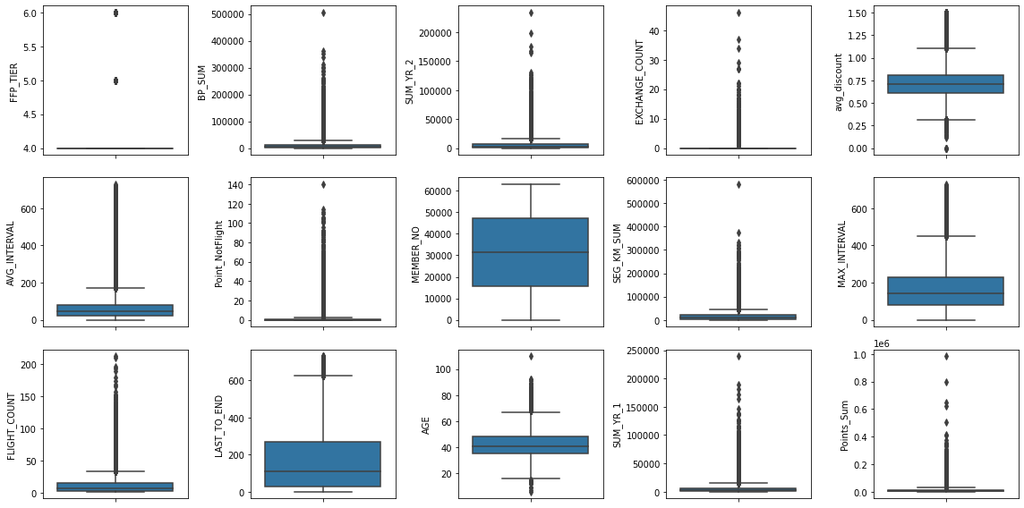

```python
plt.figure(figsize = (16,8))
for i in range(len(num)):
    plt.subplot(3, round(len(num)/3), i+1)
    sns.boxplot(y = df[num[i]], orient = 'v')
    plt.tight_layout()
```

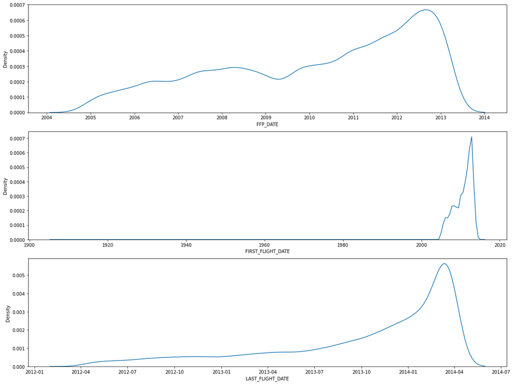

```python
plt.figure(figsize = (16,12))
for i in range(len(dateCols)):
    plt.subplot(3, round(len(dateCols)/3), i+1)
    sns.kdeplot(x = df[dateCols[i]])
    plt.tight_layout()
```

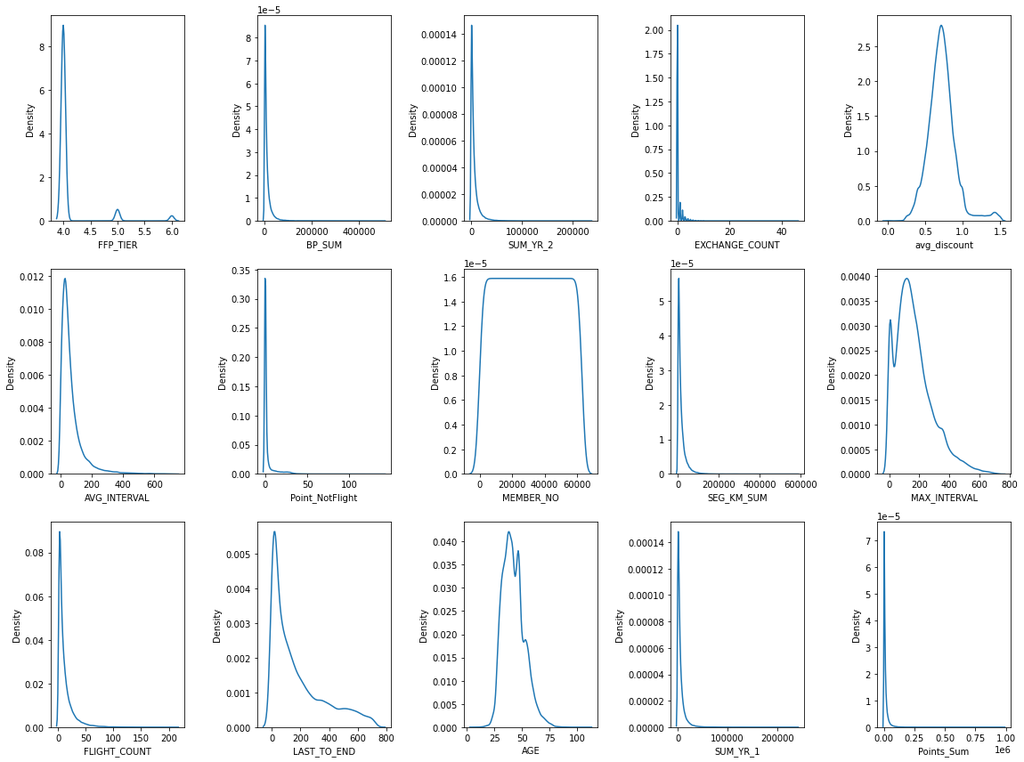

```python
plt.figure(figsize = (16,12))
for i in range(len(num)):
    plt.subplot(3, round(len(num)/3), i+1)
    sns.kdeplot(x = df[num[i]])
    plt.tight_layout()
```

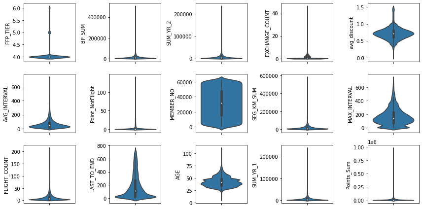

```python
plt.figure(figsize = (12,6))
for i in range(len(num)):
    plt.subplot(3, round(len(num)/3), i+1)
    sns.violinplot(y = df[num[i]])
    plt.tight_layout()
```

```python
df.columns
```

```
Index(['MEMBER_NO', 'FFP_DATE', 'FIRST_FLIGHT_DATE', 'GENDER', 'FFP_TIER',
       'WORK_CITY', 'WORK_PROVINCE', 'WORK_COUNTRY', 'AGE', 'FLIGHT_COUNT',
       'BP_SUM', 'SUM_YR_1', 'SUM_YR_2', 'SEG_KM_SUM', 'LAST_FLIGHT_DATE',
       'LAST_TO_END', 'AVG_INTERVAL', 'MAX_INTERVAL', 'EXCHANGE_COUNT',
       'avg_discount', 'Points_Sum', 'Point_NotFlight'],
      dtype='object')
```

**Sebaran data dan preprocess**

```python
for col in cat:
    print(df[col].value_counts())
    print()
```

```
Male      48134
Female    14851
Name: GENDER, dtype: int64

guangzhou    9386
beijing      7845
shanghai     5001
shenzhen     3605
dalian       1979
             ...
KASUGAI         1
hainan          1
xinxishi        1
KA              1
lingshui        1
Name: WORK_CITY, Length: 3234, dtype: int64

guangdong        17509
beijing           8014
shanghai          4998
liaoning          4182
xinjiang          2512
                 ...
YAMAGUCHI-KEN        1
AICHIKEN             1
SOUTU HOLLAND        1
xinxixian            1
JAWATIMUR            1
Name: WORK_PROVINCE, Length: 1165, dtype: int64

CN    57748
HK      991
JP      875
KR      790
US      575
      ...
CD        1
BI        1
CM        1
FL        1
GL        1
Name: WORK_COUNTRY, Length: 118, dtype: int64
```

WORK_COUNTRY mempunyai imbalance yang ekstrim, kolom ini tidak akan dipakai saat clustering karena memiliki informasi yang sedikit

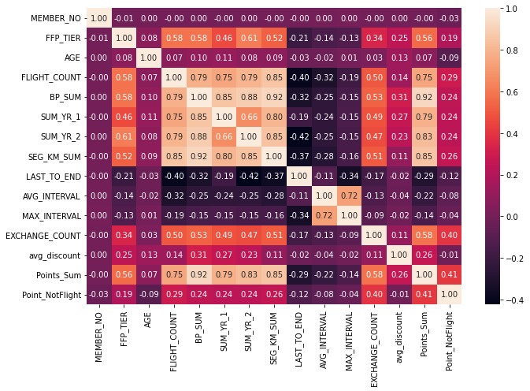

```python
plt.figure(figsize = (10,7))
sns.heatmap(df.corr(), annot = True, fmt = '.2f')
plt.tight_layout()
```

```python
cor_matrix = df.corr().abs()
upper_tri = cor_matrix.where(np.triu(np.ones(cor_matrix.shape),k=1).astype(bool))
to_drop = [column for column in upper_tri.columns if any(upper_tri[column] > 0.7)]
```

```python
to_drop
```

```
['BP_SUM', 'SUM_YR_1', 'SUM_YR_2', 'SEG_KM_SUM', 'MAX_INTERVAL', 'Points_Sum']
```

**Kolom-kolom yang berkorelasi kuat (correlation > 0.7):**

Kolom-kolom yang berkorelasi kuat ini akan di drop jika kolom yang berkorelasi kuat dengannya akan dipakai, agar tidak menimbulkan multicorelation

```python
df.columns
```

```
Index(['MEMBER_NO', 'FFP_DATE', 'FIRST_FLIGHT_DATE', 'GENDER', 'FFP_TIER',
       'WORK_CITY', 'WORK_PROVINCE', 'WORK_COUNTRY', 'AGE', 'FLIGHT_COUNT',
       'BP_SUM', 'SUM_YR_1', 'SUM_YR_2', 'SEG_KM_SUM', 'LAST_FLIGHT_DATE',
       'LAST_TO_END', 'AVG_INTERVAL', 'MAX_INTERVAL', 'EXCHANGE_COUNT',
       'avg_discount', 'Points_Sum', 'Point_NotFlight'],
      dtype='object')
```

```python
df.head(3)
```

|  | MEMBER_NO | FFP_DATE | FIRST_FLIGHT_DATE | GENDER | FFP_TIER | WORK_CITY | WORK_PROVINCE | WORK_COUNTRY | AGE | FLIGHT_COUNT | ... | SUM_YR_2 | SEG_KM_SUM | LAST_FLIGHT_DATE | LAST_TO_END | AVG_INTERVAL | MAX_INTERVAL | EXCHANGE_COUNT | avg_discount | Points_Sum | Point_NotFlight |
| --- | --- | --- | --- | --- | --- | --- | --- | --- | --- | --- | --- | --- | --- | --- | --- | --- | --- | --- | --- | --- | --- |
| 0 | 54993 | 2006-11-02 | 2008-12-24 | Male | 6 | . | beijing | CN | 31.0 | 210 | ... | 234188.0 | 580717 | 2014-03-31 | 1 | 3.483254 | 18 | 34 | 0.961639 | 619760 | 50 |
| 1 | 28065 | 2007-02-19 | 2007-08-03 | Male | 6 | NaN | beijing | CN | 42.0 | 140 | ... | 167434.0 | 293678 | 2014-03-25 | 7 | 5.194245 | 17 | 29 | 1.252314 | 415768 | 33 |
| 2 | 55106 | 2007-02-01 | 2007-08-30 | Male | 6 | . | beijing | CN | 40.0 | 135 | ... | 164982.0 | 283712 | 2014-03-21 | 11 | 5.298507 | 18 | 20 | 1.254676 | 406361 | 26 |

3 rows × 22 columns

# Feature Selection

fitur yang akan digunakan untuk clustering adalah fitur yang termasuk kedalam RFM, yaitu Recency, Frequency, dan Monetary. Fitur-fitur tersebut adalah:

- 'LAST_TO_END' : fitur ini termasuk kedalam Recency karena berisi data tentang kapan jarak waktu penerbangan terakhir ke pesanan penerbangan paling akhir
- 'LAST_FLIGHT_DATE' : fitur ini termasuk kedalam Recency karena berisi data tentang kapan terakhir kali customer terbang, nantinya akan dilakukan feature engineering pada fitur ini untuk mengambil tahun, bulan dan hari.
- 'FLIGHT_COUNT' : fitur ini termasuk kedalam Frequency karena berisi data tentang jumlah penerbangan yang telah dilakukan oleh customer
- 'SUM_YR_1' : fitur ini termasuk kedalam Monetary karena berisi data tentang revenue yang telah diberikan customer tersebut kepada perusahaan.

```python
cluster_cols = ['LAST_TO_END', 'LAST_FLIGHT_DATE', 'FLIGHT_COUNT', 'SUM_YR_1']
df_cluster = df[cluster_cols].copy()
```

```python
df_cluster.isna().sum()
```

```
LAST_TO_END           0
LAST_FLIGHT_DATE    421
FLIGHT_COUNT          0
SUM_YR_1            551
dtype: int64
```

```python
df_cluster.shape[0]
```

```
62988
```

```python
df_cluster.dropna(inplace = True)
```

```python
df_cluster.isna().sum()
```

```
LAST_TO_END         0
LAST_FLIGHT_DATE    0
FLIGHT_COUNT        0
SUM_YR_1            0
dtype: int64
```

```python
df_cluster['LAST_FLIGHT_DATE'].dt.year
```

```
0        2014
1        2014
2        2014
3        2013
4        2014
         ...
62982    2013
62983    2013
62984    2014
62985    2014
62986    2013
Name: LAST_FLIGHT_DATE, Length: 62016, dtype: int64
```

```python
df_cluster.head(3)
```

|  | LAST_TO_END | LAST_FLIGHT_DATE | FLIGHT_COUNT | SUM_YR_1 |
| --- | --- | --- | --- | --- |
| 0 | 1 | 2014-03-31 | 210 | 239560.0 |
| 1 | 7 | 2014-03-25 | 140 | 171483.0 |
| 2 | 11 | 2014-03-21 | 135 | 163618.0 |

```python
df_cluster['LAST_FLIGHT_YEAR'] = df_cluster['LAST_FLIGHT_DATE'].dt.year
df_cluster['LAST_FLIGHT_MONTH'] = df_cluster['LAST_FLIGHT_DATE'].dt.month
df_cluster['LAST_FLIGHT_DAY'] = df_cluster['LAST_FLIGHT_DATE'].dt.day
```

```python
df_cluster.head(3)
```

|  | LAST_TO_END | LAST_FLIGHT_DATE | FLIGHT_COUNT | SUM_YR_1 | LAST_FLIGHT_YEAR | LAST_FLIGHT_MONTH | LAST_FLIGHT_DAY |
| --- | --- | --- | --- | --- | --- | --- | --- |
| 0 | 1 | 2014-03-31 | 210 | 239560.0 | 2014 | 3 | 31 |
| 1 | 7 | 2014-03-25 | 140 | 171483.0 | 2014 | 3 | 25 |
| 2 | 11 | 2014-03-21 | 135 | 163618.0 | 2014 | 3 | 21 |

```python
df_cluster.drop('LAST_FLIGHT_DATE', axis = 1, inplace = True)
```

# Standardization (Feature scaling)

```python
df_cluster_std = StandardScaler().fit_transform(df_cluster)
df_cluster = pd.DataFrame(df_cluster_std, columns = df_cluster.columns)
```

```python
df_cluster.describe()
```

[output not shown]

```python
df_cluster.columns
```

```
Index(['LAST_TO_END', 'FLIGHT_COUNT', 'SUM_YR_1', 'LAST_FLIGHT_YEAR',
       'LAST_FLIGHT_MONTH', 'LAST_FLIGHT_DAY'],
      dtype='object')
```

```python
df_cluster.head()
```

|  | LAST_TO_END | FLIGHT_COUNT | SUM_YR_1 | LAST_FLIGHT_YEAR | LAST_FLIGHT_MONTH | LAST_FLIGHT_DAY |
| --- | --- | --- | --- | --- | --- | --- |
| 0 | -0.953067 | 14.064023 | 28.854805 | 0.969852 | -0.672093 | 1.581374 |
| 1 | -0.919984 | 9.094517 | 20.467597 | 0.969852 | -0.672093 | 0.892060 |
| 2 | -0.897928 | 8.739553 | 19.498615 | 0.969852 | -0.672093 | 0.432517 |
| 3 | -0.423735 | 0.788344 | 13.675112 | -0.526773 | 1.711877 | 1.006945 |
| 4 | -0.931012 | 9.946432 | 14.686599 | 0.969852 | -0.672093 | 1.121831 |

# Clustering

```python
inertia = []
silhouette = []
for i in range(2, 11):
    kmeans = KMeans(n_clusters=i, random_state=42)
    kmeans.fit(df_cluster.values)
    inertia.append(kmeans.inertia_)
    silhouette.append(silhouette_score(df_cluster, kmeans.labels_))
```

### Elbow Method

```
[247461.34147070718, 189407.80924957606, 155203.316818869, 133077.1619573789, 113208.82684598262, 99458.99996877743, 87476.79647817611, 81566.74002643226, 75672.62769805596]
```

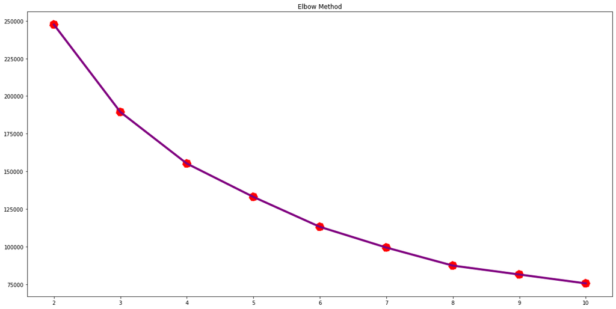

```python
print(inertia)

plt.figure(figsize=(20, 10))
# plt.plot(inertia)

sns.lineplot(x=range(2, 11), y=inertia, color='purple', linewidth = 4)
sns.scatterplot(x=range(2, 11), y=inertia, s=300, color='red',  linestyle='--')
plt.title('Elbow Method');
```

```python
inertia
```

[output not shown]

```python
for i in range(len(inertia)-1):
    percentage = ((inertia[i] - inertia[i+1])/inertia[i]) * 100
    print(f"Penurunan Inertia = {percentage}% Jumlah cluster = {i+3}")
```

[output not shown]

### Silhouette Score

```
[0.4399438730769104, 0.4541969115067205, 0.3928638875832538, 0.3519056118316658, 0.36524449097776635, 0.36828261010723784, 0.37202029059274505, 0.36440948607617907, 0.34566187289196953]
```

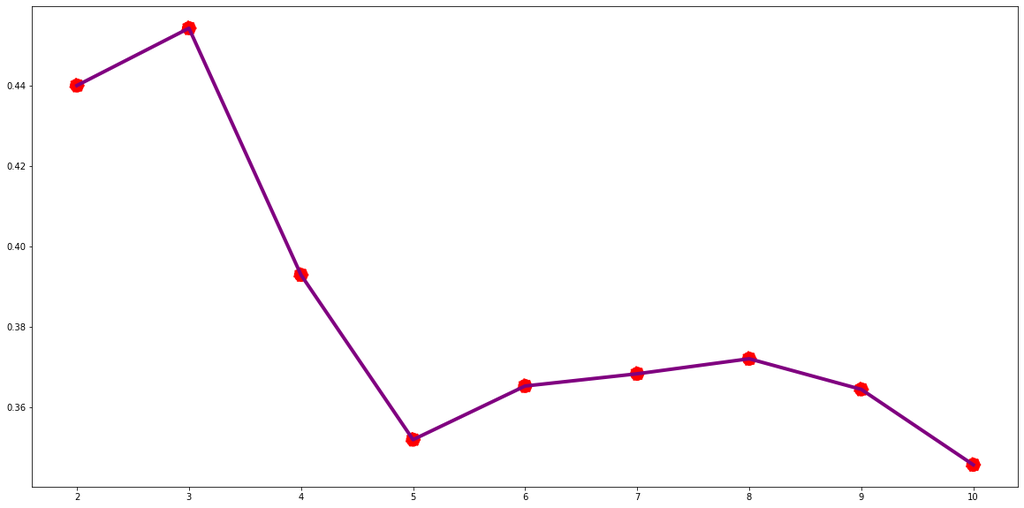

```python
print(silhouette)

plt.figure(figsize=(20, 10))

sns.lineplot(x=range(2, 11), y=silhouette, color='purple', linewidth = 4)
sns.scatterplot(x=range(2, 11), y=silhouette, s=300, color='red',  linestyle='--')
plt.title('Silhouette Score');
```

Dari penurunan diatas dapat kitalihat bahwa jumlah cluster 3 adalah yang paling optimal, karena setelah jumlah cluster 3, penurunan inertia sudah tidak terlalu signifikan, serta silhouette score sudah mulai turun.

```python
kmeans = KMeans(n_clusters=3, random_state = 42)
kmeans.fit(df_cluster.values)
```

```
KMeans(n_clusters=3, random_state=42)
```

```python
df_cluster['label'] = kmeans.labels_
```

```python
df_cluster
```

|  | LAST_TO_END | FLIGHT_COUNT | SUM_YR_1 | LAST_FLIGHT_YEAR | LAST_FLIGHT_MONTH | LAST_FLIGHT_DAY | label |
| --- | --- | --- | --- | --- | --- | --- | --- |
| 0 | -0.953067 | 14.064023 | 28.854805 | 0.969852 | -0.672093 | 1.581374 | 0 |
| 1 | -0.919984 | 9.094517 | 20.467597 | 0.969852 | -0.672093 | 0.892060 | 0 |
| 2 | -0.897928 | 8.739553 | 19.498615 | 0.969852 | -0.672093 | 0.432517 | 0 |
| 3 | -0.423735 | 0.788344 | 13.675112 | -0.526773 | 1.711877 | 1.006945 | 0 |
| 4 | -0.931012 | 9.946432 | 14.686599 | 0.969852 | -0.672093 | 1.121831 | 0 |
| ... | ... | ... | ... | ... | ... | ... | ... |
| 62011 | 1.450981 | -0.702508 | -0.659416 | -0.526773 | -1.201864 | 0.317631 | 1 |
| 62012 | 0.679039 | -0.702508 | -0.659416 | -0.526773 | 0.122563 | -0.946112 | 1 |
| 62013 | -0.467846 | -0.560522 | -0.659416 | 0.969852 | -1.201864 | -1.635427 | 2 |
| 62014 | -0.798679 | -0.702508 | -0.659416 | 0.969852 | -0.672093 | -1.635427 | 2 |
| 62015 | 1.246968 | -0.702508 | -0.659416 | -0.526773 | -0.936979 | 1.006945 | 1 |

62016 rows × 7 columns

Karena jumlah feature terlalu banyak, maka akan sulit di visualisasikan. Karena itu kita akan menggunakan PCA dan mengurangi jumlah feature menjadi 2

# PCA

```python
X = df_cluster.drop('label', axis = 1)
y = df_cluster['label']
```

```python
pca = PCA(n_components = 2)
pca.fit(X)
pcs = pca.transform(X)

df_reduced = pd.DataFrame(pcs, columns = ['PC1', 'PC2'])
```

```python
print('Explained variance:', pca.explained_variance_)
print('Explained variance ratio:', pca.explained_variance_ratio_)
```

```
Explained variance: [2.79408677 1.3427179 ]
Explained variance ratio: [0.46567362 0.22378271]
```

```python
pca.explained_variance_ratio_.sum() * 100
```

```
68.94563273311991
```

kita hanya mendapatkan 68.94% dari total variance data

```python
df_reduced['Cluster'] = y
```

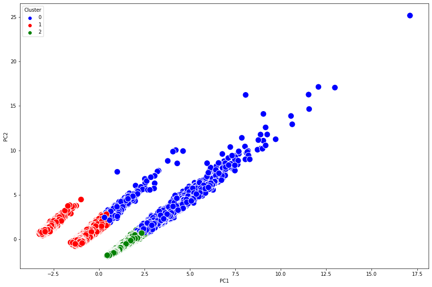

```python
fig, ax = plt.subplots(figsize=(15,10))

sns.scatterplot(
    x="PC1", y="PC2",
    hue="Cluster",
    data=df_reduced,
    palette=['blue','red','green'],
    s=160,
    ax=ax
);
```

karena terlalu banyak variance yang terbuang pada PCA maka visualisasi menjadi tidak terlalu jelas, karena itu kita akan mencoba untuk memperbanyak components pada PCA

```python
pca = PCA(n_components = 3)
pca.fit(X)
pcs = pca.transform(X)

df_reduced = pd.DataFrame(pcs, columns = ['PC1', 'PC2', 'PC3'])
```

```python
print('Explained variance:', pca.explained_variance_)
print('Explained variance ratio:', pca.explained_variance_ratio_)
```

```
Explained variance: [2.79408677 1.3427179  0.9689989 ]
Explained variance ratio: [0.46567362 0.22378271 0.16149721]
```

```python
pca.explained_variance_ratio_.sum() * 100
```

```
85.09535405874186
```

Variance yang dapat kita pertahankan dari data naik menjadi 85.09%, dengan ini informasi yang terbuang pada PCA menjadi berkurang

```python
df_reduced
```

|  | PC1 | PC2 | PC3 | Cluster |
| --- | --- | --- | --- | --- |
| 0 | 17.106138 | 25.168142 | 4.894858 | 0 |
| 1 | 12.071657 | 17.144171 | 3.625790 | 0 |
| 2 | 11.530884 | 16.276580 | 3.871368 | 0 |
| 3 | 4.226398 | 10.030444 | 1.428071 | 0 |
| 4 | 10.563057 | 13.871270 | 2.451826 | 0 |
| ... | ... | ... | ... | ... |
| 62011 | -0.996949 | -0.571410 | -0.429737 | 1 |
| 62012 | -1.300831 | -0.516396 | 0.740399 | 1 |
| 62013 | 0.572021 | -1.818402 | 1.492984 | 2 |
| 62014 | 0.460110 | -1.799244 | 1.452933 | 2 |
| 62015 | -0.920532 | -0.434151 | -1.118646 | 1 |

62016 rows × 4 columns

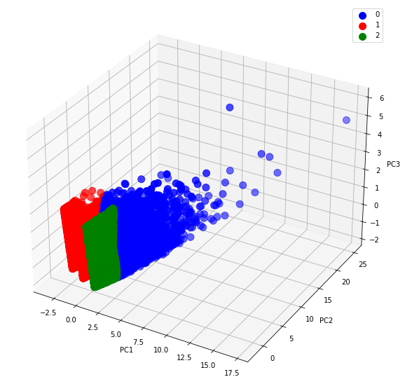

```python
fig = plt.figure(figsize=(15,10))
ax = fig.add_subplot(111, projection='3d')

ax.scatter(df_reduced[df_reduced['Cluster'] == 0]['PC1'], df_reduced[df_reduced['Cluster'] == 0]['PC2'], df_reduced[df_reduced['Cluster'] == 0]['PC3'], c='blue', s=100, label = '0')
ax.scatter(df_reduced[df_reduced['Cluster'] == 1]['PC1'], df_reduced[df_reduced['Cluster'] == 1]['PC2'], df_reduced[df_reduced['Cluster'] == 1]['PC3'], c='red', s=100, label = '1')
ax.scatter(df_reduced[df_reduced['Cluster'] == 2]['PC1'], df_reduced[df_reduced['Cluster'] == 2]['PC2'], df_reduced[df_reduced['Cluster'] == 2]['PC3'], c='green', s=100, label = '2')

plt.xlabel("PC1")
plt.ylabel("PC2")
ax.set_zlabel("PC3")
plt.legend()
plt.show()
```

Setelah menggunakan 3d plot menggunakan 3 PCA, Terlihat pembagian cluster sekarang menjadi lebih jelas, cluster terpisah secara baik

# Interpretation

```python
cluster_cols = ['LAST_TO_END', 'LAST_FLIGHT_DATE', 'FLIGHT_COUNT', 'SUM_YR_1']
```

```python
df_filtered = df.dropna(subset = cluster_cols).copy()
```

```python
df_filtered.reset_index(inplace = True)
```

```python
df_filtered['Cluster'] = y
```

```python
df_filtered
```

|  | index | MEMBER_NO | FFP_DATE | FIRST_FLIGHT_DATE | GENDER | FFP_TIER | WORK_CITY | WORK_PROVINCE | WORK_COUNTRY | AGE | ... | SEG_KM_SUM | LAST_FLIGHT_DATE | LAST_TO_END | AVG_INTERVAL | MAX_INTERVAL | EXCHANGE_COUNT | avg_discount | Points_Sum | Point_NotFlight | Cluster |
| --- | --- | --- | --- | --- | --- | --- | --- | --- | --- | --- | --- | --- | --- | --- | --- | --- | --- | --- | --- | --- | --- |
| 0 | 0 | 54993 | 2006-11-02 | 2008-12-24 | Male | 6 | . | beijing | CN | 31.0 | ... | 580717 | 2014-03-31 | 1 | 3.483254 | 18 | 34 | 0.961639 | 619760 | 50 | 0 |
| 1 | 1 | 28065 | 2007-02-19 | 2007-08-03 | Male | 6 | NaN | beijing | CN | 42.0 | ... | 293678 | 2014-03-25 | 7 | 5.194245 | 17 | 29 | 1.252314 | 415768 | 33 | 0 |
| 2 | 2 | 55106 | 2007-02-01 | 2007-08-30 | Male | 6 | . | beijing | CN | 40.0 | ... | 283712 | 2014-03-21 | 11 | 5.298507 | 18 | 20 | 1.254676 | 406361 | 26 | 0 |
| 3 | 3 | 21189 | 2008-08-22 | 2008-08-23 | Male | 5 | Los Angeles | CA | US | 64.0 | ... | 281336 | 2013-12-26 | 97 | 27.863636 | 73 | 11 | 1.090870 | 372204 | 12 | 0 |
| 4 | 4 | 39546 | 2009-04-10 | 2009-04-15 | Male | 6 | guiyang | guizhou | CN | 48.0 | ... | 309928 | 2014-03-27 | 5 | 4.788079 | 47 | 27 | 0.970658 | 338813 | 39 | 0 |
| ... | ... | ... | ... | ... | ... | ... | ... | ... | ... | ... | ... | ... | ... | ... | ... | ... | ... | ... | ... | ... | ... |
| 62011 | 62982 | 16415 | 2013-01-20 | 2013-01-20 | Female | 4 | beijing | . | CN | 35.0 | ... | 3848 | 2013-01-20 | 437 | 0.000000 | 0 | 0 | 0.000000 | 0 | 0 | 1 |
| 62012 | 62983 | 18375 | 2011-05-20 | 2013-06-05 | Female | 4 | guangzhou | guangdong | CN | 25.0 | ... | 1134 | 2013-06-09 | 297 | 4.000000 | 4 | 1 | 0.000000 | 12318 | 22 | 1 |
| 62013 | 62984 | 36041 | 2010-03-08 | 2013-09-14 | Male | 4 | foshan | guangdong | CN | 38.0 | ... | 8016 | 2014-01-03 | 89 | 37.000000 | 60 | 14 | 0.000000 | 106972 | 43 | 2 |
| 62014 | 62985 | 45690 | 2006-03-30 | 2006-12-02 | Female | 4 | guangzhou | guangdong | CN | 43.0 | ... | 2594 | 2014-03-03 | 29 | 166.000000 | 166 | 0 | 0.000000 | 0 | 0 | 2 |
| 62015 | 62986 | 61027 | 2013-02-06 | 2013-02-14 | Female | 4 | guangzhou | guangdong | CN | 36.0 | ... | 3934 | 2013-02-26 | 400 | 12.000000 | 12 | 0 | 0.000000 | 0 | 0 | 1 |

62016 rows × 24 columns

```python
df_filtered[df_filtered['Cluster'] == 0].describe()
```

|  | index | MEMBER_NO | FFP_TIER | AGE | FLIGHT_COUNT | BP_SUM | SUM_YR_1 | SUM_YR_2 | SEG_KM_SUM | LAST_TO_END | AVG_INTERVAL | MAX_INTERVAL | EXCHANGE_COUNT | avg_discount | Points_Sum | Point_NotFlight | Cluster |
| --- | --- | --- | --- | --- | --- | --- | --- | --- | --- | --- | --- | --- | --- | --- | --- | --- | --- |
| count | 4429.000000 | 4429.000000 | 4429.000000 | 4411.000000 | 4429.000000 | 4429.000000 | 4429.000000 | 4429.000000 | 4429.000000 | 4429.000000 | 4429.000000 | 4429.000000 | 4429.000000 | 4429.000000 | 4429.000000 | 4429.000000 | 4429.0 |
| mean | 3132.221269 | 31234.025288 | 4.798149 | 44.723192 | 49.603974 | 50812.580492 | 25903.074960 | 25040.801987 | 69131.386543 | 31.848047 | 16.258498 | 89.270264 | 2.060962 | 0.822966 | 59203.973132 | 8.947166 | 0.0 |
| std | 2641.958826 | 18309.656654 | 0.746196 | 9.000038 | 21.659939 | 33959.740958 | 15986.975447 | 17535.012743 | 35857.086147 | 57.911972 | 7.817653 | 47.195497 | 2.916000 | 0.201437 | 43794.733790 | 13.434051 | 0.0 |
| min | 0.000000 | 10.000000 | 4.000000 | 14.000000 | 4.000000 | 7040.000000 | 0.000000 | 0.000000 | 8648.000000 | 1.000000 | 3.433962 | 15.000000 | 0.000000 | 0.427988 | 7040.000000 | 0.000000 | 0.0 |
| 25% | 1193.000000 | 14853.000000 | 4.000000 | 38.000000 | 36.000000 | 31041.000000 | 16448.000000 | 14057.000000 | 46587.000000 | 5.000000 | 11.622642 | 59.000000 | 0.000000 | 0.702577 | 33631.000000 | 1.000000 | 0.0 |
| 50% | 2566.000000 | 30775.000000 | 5.000000 | 44.000000 | 45.000000 | 41270.000000 | 21891.000000 | 21221.000000 | 60518.000000 | 13.000000 | 15.181818 | 79.000000 | 1.000000 | 0.767931 | 46557.000000 | 4.000000 | 0.0 |
| 75% | 4458.000000 | 47166.000000 | 5.000000 | 50.000000 | 59.000000 | 58304.000000 | 30311.000000 | 31327.000000 | 81221.000000 | 31.000000 | 19.162162 | 107.000000 | 3.000000 | 0.860027 | 68620.000000 | 10.000000 | 0.0 |
| max | 32493.000000 | 62966.000000 | 6.000000 | 81.000000 | 213.000000 | 505308.000000 | 239560.000000 | 234188.000000 | 580717.000000 | 461.000000 | 145.000000 | 572.000000 | 46.000000 | 1.500000 | 795398.000000 | 140.000000 | 0.0 |

```python
df_filtered[df_filtered['Cluster'] == 1].describe()
```

|  | index | MEMBER_NO | FFP_TIER | AGE | FLIGHT_COUNT | BP_SUM | SUM_YR_1 | SUM_YR_2 | SEG_KM_SUM | LAST_TO_END | AVG_INTERVAL | MAX_INTERVAL | EXCHANGE_COUNT | avg_discount | Points_Sum | Point_NotFlight | Cluster |
| --- | --- | --- | --- | --- | --- | --- | --- | --- | --- | --- | --- | --- | --- | --- | --- | --- | --- |
| count | 33086.000000 | 33086.000000 | 33086.000000 | 32832.000000 | 33086.000000 | 33086.000000 | 33086.000000 | 32948.000000 | 33086.000000 | 33086.000000 | 33086.000000 | 33086.000000 | 33086.000000 | 33086.000000 | 33086.000000 | 33086.000000 | 33086.0 |
| mean | 39052.391011 | 31467.620202 | 4.018346 | 42.275341 | 6.191592 | 5550.603851 | 3415.377782 | 2121.192303 | 9387.285922 | 295.761803 | 70.994663 | 151.929668 | 0.116635 | 0.713656 | 6416.791060 | 1.900925 | 1.0 |
| std | 15505.434392 | 18185.866450 | 0.174882 | 10.202069 | 5.212221 | 6006.388451 | 3791.601582 | 3024.453722 | 8940.397095 | 169.786003 | 77.590210 | 120.761282 | 0.554016 | 0.190764 | 8799.261008 | 5.917996 | 0.0 |
| min | 168.000000 | 1.000000 | 4.000000 | 7.000000 | 2.000000 | 0.000000 | 0.000000 | 0.000000 | 368.000000 | 92.000000 | 0.000000 | 0.000000 | 0.000000 | 0.000000 | 0.000000 | 0.000000 | 1.0 |
| 25% | 27256.250000 | 15652.250000 | 4.000000 | 35.000000 | 3.000000 | 1844.000000 | 960.000000 | 0.000000 | 3682.000000 | 152.000000 | 24.000000 | 56.000000 | 0.000000 | 0.595102 | 2016.000000 | 0.000000 | 1.0 |
| 50% | 40803.500000 | 31498.500000 | 4.000000 | 41.000000 | 4.000000 | 3594.000000 | 2269.000000 | 1175.500000 | 6447.500000 | 245.000000 | 49.000000 | 134.000000 | 0.000000 | 0.707179 | 4012.000000 | 0.000000 | 1.0 |
| 75% | 52266.750000 | 47284.500000 | 4.000000 | 48.000000 | 8.000000 | 7023.000000 | 4589.750000 | 2965.000000 | 11961.500000 | 413.000000 | 89.333333 | 219.000000 | 0.000000 | 0.816989 | 7947.750000 | 0.000000 | 1.0 |
| max | 62986.000000 | 62988.000000 | 6.000000 | 110.000000 | 47.000000 | 153078.000000 | 37851.000000 | 69500.000000 | 130168.000000 | 731.000000 | 636.000000 | 636.000000 | 27.000000 | 1.500000 | 647113.000000 | 111.000000 | 1.0 |

Cluster 1 memiliki median tier dari Frequent Flyer Program 4, umur 41, jumlah penerbangan 4, rencana perjalanan 3594, Fare Revenue 2269, Votes Prices 1175.5, Total jarak(km) penerbangan yg sudah dilakukan 6447, Jarak waktu penerbangan terakhir ke pesanan penerbangan paling akhir 245 hari, Rata-rata jarak waktu 49 menit, Maksimal jarak waktu 134 menit, Jumlah penukaran 0, rata rata discount yang didapat 0.7%, Jumlah poin yang didapat 4012, point yang tidak digunakan 0

```python
df_filtered[df_filtered['Cluster'] == 2].describe()
```

|  | index | MEMBER_NO | FFP_TIER | AGE | FLIGHT_COUNT | BP_SUM | SUM_YR_1 | SUM_YR_2 | SEG_KM_SUM | LAST_TO_END | AVG_INTERVAL | MAX_INTERVAL | EXCHANGE_COUNT | avg_discount | Points_Sum | Point_NotFlight | Cluster |
| --- | --- | --- | --- | --- | --- | --- | --- | --- | --- | --- | --- | --- | --- | --- | --- | --- | --- |
| count | 24501.000000 | 24501.000000 | 24501.000000 | 24358.000000 | 24501.000000 | 24501.000000 | 24501.000000 | 24501.000000 | 24501.000000 | 24501.000000 | 24501.000000 | 24501.000000 | 24501.000000 | 24501.000000 | 24501.000000 | 24501.000000 | 24501.0 |
| mean | 26036.964777 | 31568.392515 | 4.091262 | 42.395312 | 12.781437 | 11127.059100 | 4253.053141 | 6861.360761 | 18404.105139 | 34.887800 | 73.554636 | 201.328436 | 0.284029 | 0.714513 | 12561.206114 | 2.754337 | 2.0 |
| std | 15933.085789 | 18153.761237 | 0.342734 | 9.564218 | 8.887365 | 9853.513181 | 4305.273788 | 6200.229112 | 14398.582107 | 26.369326 | 81.397540 | 125.591647 | 0.859673 | 0.168260 | 13328.654128 | 7.075045 | 0.0 |
| min | 70.000000 | 3.000000 | 4.000000 | 6.000000 | 2.000000 | 0.000000 | 0.000000 | 0.000000 | 368.000000 | 1.000000 | 0.000000 | 0.000000 | 0.000000 | 0.000000 | 0.000000 | 0.000000 | 2.0 |
| 25% | 12718.000000 | 16010.000000 | 4.000000 | 35.000000 | 6.000000 | 4120.000000 | 729.000000 | 2614.000000 | 7716.000000 | 12.000000 | 30.363636 | 115.000000 | 0.000000 | 0.616559 | 4569.000000 | 0.000000 | 2.0 |
| 50% | 22983.000000 | 31601.000000 | 4.000000 | 41.000000 | 11.000000 | 8632.000000 | 2970.000000 | 5111.000000 | 15015.000000 | 29.000000 | 48.142857 | 172.000000 | 0.000000 | 0.704540 | 9476.000000 | 0.000000 | 2.0 |
| 75% | 37639.000000 | 47252.000000 | 4.000000 | 48.000000 | 18.000000 | 15356.000000 | 6648.000000 | 9170.000000 | 25388.000000 | 57.000000 | 83.875000 | 261.000000 | 0.000000 | 0.791367 | 16962.000000 | 1.000000 | 2.0 |
| max | 62985.000000 | 62986.000000 | 6.000000 | 89.000000 | 55.000000 | 193780.000000 | 30960.000000 | 110100.000000 | 209911.000000 | 91.000000 | 728.000000 | 728.000000 | 22.000000 | 1.487201 | 985572.000000 | 104.000000 | 2.0 |

Cluster 2 memiliki median tier dari Frequent Flyer Program 4, umur 41, jumlah penerbangan 11, rencana perjalanan 8632, Fare Revenue 2970, Votes Prices 5111, Total jarak(km) penerbangan yg sudah dilakukan 15015, Jarak waktu penerbangan terakhir ke pesanan penerbangan paling akhir 29 hari, Rata-rata jarak waktu 48 menit, Maksimal jarak waktu 172 menit, Jumlah penukaran 0, rata rata discount yang didapat 0.7%, Jumlah poin yang didapat 9476, point yang tidak digunakan 0

Dari ciri-ciri dari setiap cluster diatas dapat disimpulkan bahwa:

- Cluster 0: **First class customer**, mempunyai tier yang tinggi, serta sering memakai jasa penerbangan walaupun jaraknya hanya dekat sekalipun. jenis penerbangan yang rata-rata dipakai oleh customer ini adalah penerbangan yang mahal (fare revenue yang besar dibandingkan jumlah dan jarak penerbangan)
- Cluster 1: **Business class customer**, mempunyai tier yang rendah, serta jarang memakai jasa penerbangan, rata-rata penerbangan yang dilakukan adalah penerbangan jauh dengan waktu yang cukup lama. Jenis penerbangan yang rata-rata dipakai oleh customer ini adalah penerbangan yang sedang harganya (fare revenue yang lumayan besar dibandingkan jumlah dan jarak penerbangan)
- Cluster 2: **Economy class customer**, mempunyai tier yang rendah, namun lumayan sering memakai jasa penerbangan, namun rata-rata penerbangan yang dilakukan adalah penerbangan yang murah (fare revenue yang sedikit dibandingkan jumlah dan jarak penerbangan),

## Rekomendasi bisnis

Customer yang berada di cluster 1 (business class customer) jarang melakukan penerbangan, jika dilihat avg discount yang dimiliki lebih rendah daripada customer di cluster 0 yang sering melakukan penerbangan, dan terlihat jika customer ini enggan untuk naik pesawat economy yang murah. Selain itu customer di cluster 1 memiliki jumlah paling banyak.

Karena itulah rekomendasi bisnis yang tepat untuk dilakukan adalah membuat seasonal discount untuk penerbangan jarak jauh di kelas bisnis agar customer di cluster 1 dapat lebih sering terbang.